# Appendix F — Python Random Generation

**STAT 418 · Computational Data Science** · runnable companion to the Appendix F webbook.

Theoretical understanding of probability distributions does not, by itself, generate data. When we need 10,000 bootstrap samples, a million Monte-Carlo iterations, or posterior draws from an MCMC chain, we have to bridge the gap from a mathematical density $f(x\mid\theta)$ to actual numbers on the machine. This appendix is that bridge: a hands-on tour of Python's ecosystem for random number generation — the standard-library `random` module, NumPy's modern `Generator` API, and `scipy.stats` — and the seeding / parallel-stream discipline that keeps simulation **reproducible**.

Everything here is executed: each printed statistic is produced *live* by a seeded generator, so the numbers (and figures) are exactly what you would get on your own machine.

## Learning outcomes

By the end you can:

1. Explain how a **pseudo-random number generator (PRNG)** turns a deterministic algorithm into "randomness," and why an explicit **seed** is what makes scientific work reproducible.
2. Use the standard-library **`random`** module — scalar draws, sequence operations (`choice` / `choices` / `sample` / `shuffle`), the eleven classic distribution generators, and `seed` / `getstate` / `setstate`.
3. Drive NumPy's **`Generator`** API (`default_rng`) for fast vectorized draws, univariate and multivariate distributions, and array sampling utilities.
4. Build the complete **`scipy.stats`** toolkit — the frozen-distribution pattern, the unified `pdf`/`cdf`/`ppf`/`rvs`/`fit` interface, and the parameterization gotchas (rate vs scale) that cause endless bugs.
5. Manage **parallel random streams** correctly with `SeedSequence.spawn()`, and demonstrate why sharing one `Generator` across workers breaks reproducibility.

## Section map

| § | Topic | What you run |
| --- | --- | --- |
| F.1 | The Python ecosystem at a glance | `random` vs NumPy vs SciPy decision table |
| F.2 | Understanding pseudo-randomness | reproducibility demo · Mersenne Twister vs PCG64 · uniformity + independence figure |
| F.3 | The standard library `random` | basic draws · sequence ops · distribution generators · seed/state |
| F.4 | NumPy: fast vectorized sampling | `Generator` API · performance figure · distribution gallery · multivariate · sampling utilities · parallel streams |
| F.5 | SciPy stats: the complete toolkit | frozen distributions · 4-panel methods figure · parameterization · Gamma fit + KS test |
| F.6 | Library selection guide | when to use which (and how to combine them) |
| F.7 | Practice problem | reproducibility & parallel simulation (full worked solution) |

```python
import sys
import numpy as np
import pandas as pd
import matplotlib.pyplot as plt
import random
import time
from statistics import mean, pvariance
from collections import Counter
from scipy import stats
from numpy.random import SeedSequence, default_rng
%matplotlib inline

np.random.seed(418)            # reproducibility (STYLE.md contract)
random.seed(418)
plt.rcParams.update({
    'figure.figsize': (7.2, 4.2), 'figure.dpi': 110,
    'axes.grid': True, 'grid.alpha': 0.25,
    'axes.spines.top': False, 'axes.spines.right': False,
    'font.size': 11,
})
BLUE, RED, GREEN, ORANGE, PURPLE = '#4C72B0', '#C44E52', '#55A868', '#DD8452', '#8172B3'

import scipy
print('environment ready · numpy', np.__version__, '· scipy', scipy.__version__,
      '· python', sys.version.split()[0])
```

```
environment ready · numpy 1.26.4 · scipy 1.15.3 · python 3.10.14
```

## F.1 — The Python ecosystem at a glance

There is no single "random" library in Python; there is a *layered ecosystem*, and the right choice depends on the task.

| Category | Library | Why you might pick it | Best for |
| --- | --- | --- | --- |
| **Standard library** | `random` | Always available; quick scalar draws; simple shuffles; 11 classic distributions | Teaching, prototyping, dependency-free scripts |
| **Scientific computing** | `numpy.random` | Vectorized C core; ~5–10× faster for simple draws; array output; 35+ distributions | Monte Carlo, bootstrap, large-scale simulation |
| **Statistical modeling** | `scipy.stats` | 100+ distributions; PDF/CDF/PPF/fitting; statistical tests | Distribution fitting, hypothesis testing |
| **Probabilistic programming** | PyMC, Stan | High-level model syntax; MCMC & VI engines | Complex Bayesian models (Chapter 5) |

**Rule of thumb.**

- Need just a few random numbers? → the `random` module
- Need arrays of random numbers fast? → NumPy `Generator`
- Need probability calculations (PDF, CDF, quantiles)? → `scipy.stats`
- Building a Bayesian model? → PyMC / Stan (Chapter 5)

The rest of the appendix takes these one layer at a time, then closes with a worked parallel-simulation problem that ties them together.

## F.2 — Understanding pseudo-random number generation

Computers are **deterministic**: given the same input they produce the same output. So how do they produce "random" numbers? A **pseudo-random number generator (PRNG)** is a deterministic algorithm that produces a sequence which — although entirely predictable from the algorithm and its starting point — *passes stringent statistical tests for randomness*. When you call `random.random()` you are evaluating a formula that computes the next number in a deterministic stream.

That determinism is a feature, not a bug:

1. **Reproducibility** — the same **seed** gives exactly the same sequence, so others can verify your bootstrap / Monte-Carlo computation to the bit.
2. **Debugging** — fix the seed to reproduce a problematic run.
3. **Testing** — stochastic code can have deterministic pass/fail criteria.

A sequence $u_1, u_2, \ldots$ behaves like independent $\text{Uniform}(0,1)$ draws if it has **uniformity** (values spread evenly over $[0,1)$), **independence** (knowing $u_t$ tells you nothing about $u_{t+1}$), a **long period** before repeating, and good **high-dimensional equidistribution**. We demonstrate the first two below.

```python
# Reproducibility: same seed -> identical sequence (the whole point of a PRNG).
random.seed(42)
run1 = [random.random() for _ in range(5)]
random.seed(42)                       # reset to the same seed
run2 = [random.random() for _ in range(5)]
random.seed(123)                      # a different seed
run3 = [random.random() for _ in range(5)]

print('Run 1 (seed 42):', [f'{x:.4f}' for x in run1])
print('Run 2 (seed 42):', [f'{x:.4f}' for x in run2])
print('  identical?    ', run1 == run2)
print('Run 3 (seed 123):', [f'{x:.4f}' for x in run3], '  <- different seed, different stream')

# State save / restore: pause and resume the EXACT same stream.
random.seed(42)
_ = [random.random() for _ in range(100)]   # advance the state
saved = random.getstate()                    # capture the full Mersenne-Twister state
batch1 = [random.random() for _ in range(5)]
random.setstate(saved)                       # rewind to the saved point
batch2 = [random.random() for _ in range(5)]
print('\nState save/restore -> batches match:', batch1 == batch2)
```

```
Run 1 (seed 42): ['0.6394', '0.0250', '0.2750', '0.2232', '0.7365']
Run 2 (seed 42): ['0.6394', '0.0250', '0.2750', '0.2232', '0.7365']
  identical?     True
Run 3 (seed 123): ['0.0524', '0.0872', '0.4072', '0.1077', '0.9012']   <- different seed, different stream

State save/restore -> batches match: True
```

**Two PRNGs you will actually use.**

|  | Python `random` (**Mersenne Twister**, MT19937) | NumPy `Generator` (**PCG64**) |
| --- | --- | --- |
| Period | $2^{19937}-1 \approx 10^{6001}$ | $2^{128}$ |
| State size | 624 × 32-bit ints (≈19,968 bits) | 256 bits |
| Statistical quality | fails 2 linear-complexity tests of BigCrush | passes BigCrush |
| Parallel streams | manual | `SeedSequence.spawn()` (jumpable) |
| Crypto-secure? | **no** (use `secrets` for that) | **no** |

The Mersenne Twister has a gigantic period and 623-dimensional equidistribution, which is why it served as a default for decades. NumPy's **PCG64** has a much smaller state, passes more stringent tests, and is *jumpable* — the property that makes safe parallel streams cheap (F.4). For new scientific code, prefer PCG64 via `default_rng`. The figure below checks the two headline criteria — **uniformity** and **independence** — for a PCG64 stream.

```
Uniformity  : chi-square = 24.7  (5% critical = 36.4) -> PASS
Independence: lag-1 autocorrelation = -0.0003  (target ~0)
```

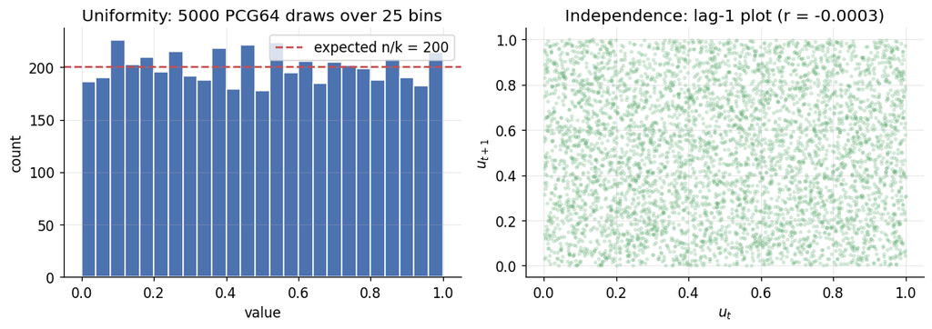

```python
# Figure: do PCG64 draws look uniform AND independent?
rng = np.random.default_rng(2718)
u = rng.random(5000)

# uniformity via a chi-square goodness-of-fit over 25 equal bins;
# independence via the lag-1 autocorrelation (should be ~0).
k = 25
counts, _ = np.histogram(u, bins=k, range=(0, 1))
expected = len(u) / k
chi2 = ((counts - expected) ** 2 / expected).sum()
chi2_crit = stats.chi2.ppf(0.95, k - 1)
lag1 = np.corrcoef(u[:-1], u[1:])[0, 1]
print(f'Uniformity  : chi-square = {chi2:.1f}  (5% critical = {chi2_crit:.1f}) -> '
      f'{"PASS" if chi2 < chi2_crit else "FAIL"}')
print(f'Independence: lag-1 autocorrelation = {lag1:+.4f}  (target ~0)')

fig, axes = plt.subplots(1, 2, figsize=(10.5, 3.8))
axes[0].hist(u, bins=k, range=(0, 1), color=BLUE, edgecolor='white')
axes[0].axhline(expected, color=RED, ls='--', lw=1.6, label=f'expected n/k = {expected:.0f}')
axes[0].set_xlabel('value'); axes[0].set_ylabel('count')
axes[0].set_title(f'Uniformity: 5000 PCG64 draws over {k} bins'); axes[0].legend()
axes[1].scatter(u[:-1], u[1:], s=5, alpha=0.18, color=GREEN)
axes[1].set_xlabel(r'$u_t$'); axes[1].set_ylabel(r'$u_{t+1}$')
axes[1].set_title(f'Independence: lag-1 plot (r = {lag1:+.4f})')
plt.tight_layout(); plt.show()
```

**Read-out.** The histogram is flat to within sampling noise (the chi-square statistic sits below its 5% critical value), and the lag-1 plot is a structureless square with a near-zero autocorrelation — exactly what "uniform and independent" should look like. A *bad* generator would show stripes or clustering in the right-hand panel. This is the empirical content behind "PCG64 passes BigCrush": the stream is deterministic, yet it is statistically indistinguishable from real uniform noise at the orders we sample.

## F.3 — The standard library: the `random` module

The `random` module ships with every Python install — no `pip install`. It is ideal for teaching, prototyping, and dependency-free scripts. Everything is built on $\text{Uniform}(0,1)$:

| Function | Output | Notes |
| --- | --- | --- |
| `random.random()` | `float` | Uniform on $[0,1)$; the fundamental building block |
| `random.uniform(a, b)` | `float` | Uniform on $[a,b]$; implemented as `a + (b-a)*random()` |
| `random.randint(a, b)` | `int` | Discrete uniform on $\{a,\dots,b\}$ — **inclusive both ends** |
| `random.randrange(start, stop, step)` | `int` | Like `range()` but a random element — **half-open** |

Use `random()` for unit-interval floats, `uniform(a, b)` for self-documenting intervals, and `randint(a, b)` for dice rolls and indices.

```python
random.seed(42)
n = 10000

# U(0,1)
u01 = [random.random() for _ in range(n)]
print(f'U(0,1)  n={n}:  mean = {mean(u01):.5f} (theory 0.5)   '
      f'var = {pvariance(u01):.5f} (theory 0.08333)')

# U(a,b)
a, b = 5, 15
uab = [random.uniform(a, b) for _ in range(n)]
print(f'U({a},{b}):       mean = {mean(uab):.4f} (theory {(a+b)/2})        '
      f'var = {pvariance(uab):.4f} (theory {(b-a)**2/12:.4f})')

# discrete uniform (a die)
dice = [random.randint(1, 6) for _ in range(n)]
print(f'randint(1,6):  mean = {mean(dice):.4f} (theory 3.5)   '
      f'counts = {dict(sorted(Counter(dice).items()))}')
```

```
U(0,1)  n=10000:  mean = 0.50025 (theory 0.5)   var = 0.08276 (theory 0.08333)
U(5,15):       mean = 10.0248 (theory 10.0)        var = 8.4013 (theory 8.3333)
randint(1,6):  mean = 3.5003 (theory 3.5)   counts = {1: 1647, 2: 1679, 3: 1646, 4: 1722, 5: 1664, 6: 1642}
```

### Random operations on sequences

Beyond generating numbers we often sample from an **existing sequence** — selecting survey respondents, shuffling treatments, dealing cards.

| Function | Returns | Replacement? | Weights? | When to use |
| --- | --- | --- | --- | --- |
| `choice(seq)` | one element | — | no | pick a single winner / coin-flip a label |
| `choices(seq, k=, weights=)` | list of `k` | **with** | yes | bootstrap, Monte-Carlo from a categorical |
| `sample(seq, k)` | `k` **unique** | **without** | no | deal cards, a CV hold-out subset |
| `shuffle(seq)` | `None` (in place) | — | — | permute a deck / treatment order |

**Key distinction:** `choices` (with replacement) allows duplicates — the bootstrap; `sample` (without replacement) guarantees uniqueness — survey sampling.

```python
random.seed(42)

# choice: a single random element
volunteers = ['Alice', 'Bob', 'Carol', 'Deepak', 'Eve']
print("today's volunteer:", random.choice(volunteers))

# choices: weighted sampling WITH replacement (a loaded die)
faces = [1, 2, 3, 4, 5, 6]
weights = [0.05, 0.10, 0.15, 0.20, 0.25, 0.25]   # biased toward high faces
rolls = random.choices(faces, weights=weights, k=10000)
print('\nloaded die — empirical vs target probability:')
for face, target in zip(faces, weights):
    print(f'  face {face}: {rolls.count(face)/len(rolls):.3f}  (target {target:.2f})')

# sample: WITHOUT replacement (a 5-card poker hand)
deck = [f'{r}{s}' for s in 'SHDC' for r in 'A23456789TJQK']
print('\npoker hand (sample, no replacement):', random.sample(deck, 5))

# shuffle: in place -> works only on MUTABLE sequences (lists)
items = list(range(10))
random.shuffle(items)
print('shuffled list:', items)
text = 'HELLO'                              # strings are immutable: convert first
letters = list(text); random.shuffle(letters)
print('shuffled string:', ''.join(letters))
```

```
today's volunteer: Alice

loaded die — empirical vs target probability:
  face 1: 0.046  (target 0.05)
  face 2: 0.106  (target 0.10)
  face 3: 0.144  (target 0.15)
  face 4: 0.203  (target 0.20)
  face 5: 0.255  (target 0.25)
  face 6: 0.246  (target 0.25)

poker hand (sample, no replacement): ['AC', '6C', 'TC', 'KC', '3S']
shuffled list: [3, 8, 2, 0, 7, 9, 4, 6, 1, 5]
shuffled string: OHLLE
```

### Distribution generators (and the parameterization trap)

`random` provides eleven classic continuous generators. The parameterization is the thing to watch — `expovariate` takes a **rate** $\lambda$ (mean $1/\lambda$), while `gammavariate(alpha, beta)` takes shape $\alpha$ and **scale** $\beta$ (mean $\alpha\beta$). We verify a handful against their theoretical moments — the single most reliable way to catch a parameterization mistake.

```python
random.seed(42)
n = 10000

# (name, sampler, theory mean, theory variance)
specs = [
    ('Normal(0,1)',       lambda: random.gauss(0, 1),         0.0,        1.0),
    ('Exponential(lam=1)', lambda: random.expovariate(1),      1.0,        1.0),
    ('Gamma(a=2, b=3)',   lambda: random.gammavariate(2, 3),  2*3,        2*3**2),
    ('Beta(2,5)',         lambda: random.betavariate(2, 5),   2/7,        (2*5)/(49*8)),
]
rows = []
for name, samp, mu_th, var_th in specs:
    xs = [samp() for _ in range(n)]
    rows.append([name, mean(xs), mu_th, pvariance(xs), var_th])
tab = pd.DataFrame(rows, columns=['distribution', 'sample_mu', 'theory_mu',
                                  'sample_var', 'theory_var'])
print(tab.round(4).to_string(index=False))
print('\nSample moments track theory -> the parameterizations are correct.')
print('Reminder: expovariate uses RATE (mean = 1/rate); gammavariate uses SCALE.')
```

```
      distribution  sample_mu  theory_mu  sample_var  theory_var
       Normal(0,1)    -0.0117     0.0000      0.9991      1.0000
Exponential(lam=1)     1.0057     1.0000      0.9780      1.0000
   Gamma(a=2, b=3)     5.9748     6.0000     17.4618     18.0000
         Beta(2,5)     0.2848     0.2857      0.0253      0.0255

Sample moments track theory -> the parameterizations are correct.
Reminder: expovariate uses RATE (mean = 1/rate); gammavariate uses SCALE.
```

## F.4 — NumPy: fast vectorized random sampling

For serious work — Monte Carlo, bootstrap, machine learning — NumPy's random module is the default. It is typically **5–10× faster** than a Python loop for simple draws (more for heavier distributions), returns **arrays** in the structure you already use for linear algebra, and offers far more distributions.

NumPy has two APIs: a **legacy** one (`np.random.rand`, …) backed by hidden global state, and the modern **`Generator`** API built around explicit objects. *Always use the modern API* — no hidden global state, clear reproducibility, parallel safety, and the better PCG64 algorithm.

```python
# The modern Generator API: create an explicit, seeded generator.
rng = np.random.default_rng(42)

uniforms = rng.random(10)            # 10 U(0,1)
normals = rng.standard_normal(10)    # 10 N(0,1)
integers = rng.integers(1, 7, 10)    # 10 dice rolls in {1,...,6}  (high EXCLUSIVE)
print('uniforms:', uniforms[:5].round(4))
print('normals :', normals[:5].round(4))
print('integers:', integers)
print('\nWhy explicit generators: no hidden global state, pass rng to functions,')
print('independent streams per worker, and PCG64 beats Mersenne Twister.')
```

```
uniforms: [0.774  0.4389 0.8586 0.6974 0.0942]
normals : [0.8794 0.7778 0.066  1.1272 0.4675]
integers: [1 5 5 3 1 6 3 6 5 5]

Why explicit generators: no hidden global state, pass rng to functions,
independent streams per worker, and PCG64 beats Mersenne Twister.
```

```
Python loop : 0.0660 s
NumPy call  : 0.0059 s
Speedup     : 11.2x  (typical 5-10x for simple draws; more for heavier ones)
```

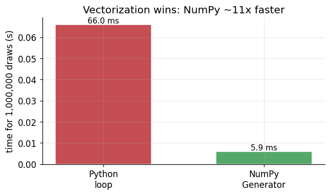

```python
# Performance: a Python loop vs one vectorized NumPy call (1,000,000 draws).
N = 1_000_000

random.seed(42)
t = time.perf_counter()
_py = [random.random() for _ in range(N)]
py_time = time.perf_counter() - t

rng = np.random.default_rng(42)
t = time.perf_counter()
_np = rng.random(N)
np_time = time.perf_counter() - t

speedup = py_time / np_time
print(f'Python loop : {py_time:.4f} s')
print(f'NumPy call  : {np_time:.4f} s')
print(f'Speedup     : {speedup:.1f}x  (typical 5-10x for simple draws; more for heavier ones)')

fig, ax = plt.subplots(figsize=(6.0, 3.6))
bars = ax.bar(['Python\nloop', 'NumPy\nGenerator'], [py_time, np_time],
              color=[RED, GREEN], edgecolor='white', width=0.6)
for b, v in zip(bars, [py_time, np_time]):
    ax.text(b.get_x()+b.get_width()/2, v, f'{v*1000:.1f} ms', ha='center', va='bottom', fontsize=10)
ax.set_ylabel('time for 1,000,000 draws (s)')
ax.set_title(f'Vectorization wins: NumPy ~{speedup:.0f}x faster')
plt.tight_layout(); plt.show()
```

### Univariate distributions

`default_rng` covers every distribution from the probability-distributions appendix — continuous and discrete. Mind the conventions: `exponential(scale=...)` uses the **scale** (= mean = $1/\lambda$), `gamma(shape, scale)` uses shape and **scale**, and `poisson(lam=...)` takes the rate. The gallery below draws 10,000 from each of six families and overlays the theoretical density / mass.

```python
rng = np.random.default_rng(42)
n = 10000

normal = rng.normal(loc=100, scale=15, size=n)      # N(100, 15^2)
exponential = rng.exponential(scale=2, size=n)       # Exp, mean = 2
gamma = rng.gamma(shape=2, scale=3, size=n)          # Gamma(k=2, theta=3), mean 6
beta = rng.beta(a=2, b=5, size=n)                    # Beta(2,5), mean 2/7
binomial = rng.binomial(n=20, p=0.3, size=n)         # Binom(20, 0.3), mean 6
poisson = rng.poisson(lam=5, size=n)                 # Poisson(5), mean=var=5

print(f'N(100,15^2): mean={normal.mean():.2f}  std={normal.std():.2f}  (theory 100, 15)')
print(f'Exp(scale=2): mean={exponential.mean():.3f}  (theory 2)')
print(f'Gamma(2,3):  mean={gamma.mean():.3f}  (theory 6)')
print(f'Beta(2,5):   mean={beta.mean():.4f}  (theory {2/7:.4f})')
print(f'Binom(20,.3):mean={binomial.mean():.3f}  (theory 6)')
print(f'Poisson(5):  mean={poisson.mean():.3f}  var={poisson.var():.3f}  (theory 5, 5)')
```

```
N(100,15^2): mean=99.85  std=15.09  (theory 100, 15)
Exp(scale=2): mean=2.010  (theory 2)
Gamma(2,3):  mean=6.034  (theory 6)
Beta(2,5):   mean=0.2851  (theory 0.2857)
Binom(20,.3):mean=5.987  (theory 6)
Poisson(5):  mean=4.993  var=5.001  (theory 5, 5)
```

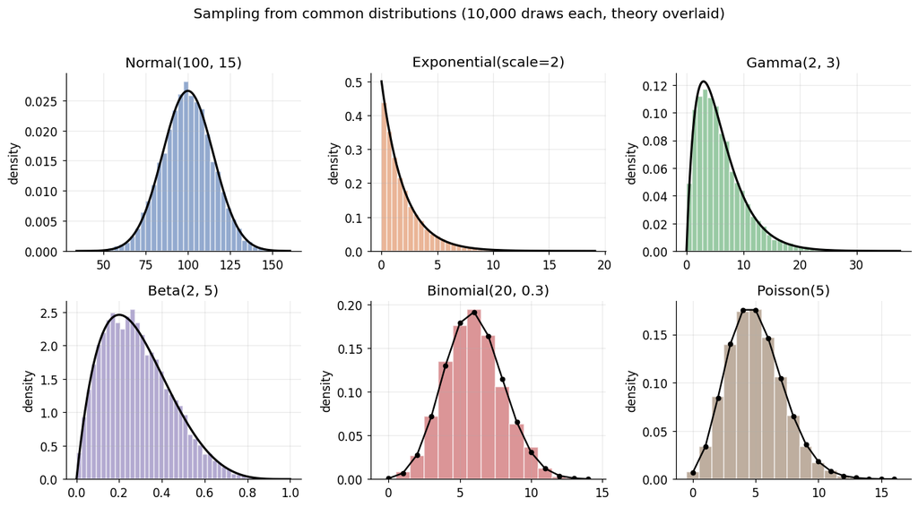

```python
# Figure: six-distribution gallery, histogram + theoretical density / pmf overlay.
fig, axes = plt.subplots(2, 3, figsize=(12, 6.4))

axes[0,0].hist(normal, bins=40, density=True, color=BLUE, alpha=0.6, edgecolor='white')
xx = np.linspace(normal.min(), normal.max(), 200)
axes[0,0].plot(xx, stats.norm.pdf(xx, 100, 15), color='k', lw=2)
axes[0,0].set_title('Normal(100, 15)')

axes[0,1].hist(exponential, bins=40, density=True, color=ORANGE, alpha=0.6, edgecolor='white')
xx = np.linspace(0, exponential.max(), 200)
axes[0,1].plot(xx, stats.expon.pdf(xx, scale=2), color='k', lw=2)
axes[0,1].set_title('Exponential(scale=2)')

axes[0,2].hist(gamma, bins=40, density=True, color=GREEN, alpha=0.6, edgecolor='white')
xx = np.linspace(0, gamma.max(), 200)
axes[0,2].plot(xx, stats.gamma.pdf(xx, a=2, scale=3), color='k', lw=2)
axes[0,2].set_title('Gamma(2, 3)')

axes[1,0].hist(beta, bins=40, density=True, color=PURPLE, alpha=0.6, edgecolor='white')
xx = np.linspace(0, 1, 200)
axes[1,0].plot(xx, stats.beta.pdf(xx, 2, 5), color='k', lw=2)
axes[1,0].set_title('Beta(2, 5)')

kk = np.arange(0, binomial.max()+1)
axes[1,1].hist(binomial, bins=np.arange(-0.5, binomial.max()+1.5), density=True,
               color=RED, alpha=0.6, edgecolor='white')
axes[1,1].plot(kk, stats.binom.pmf(kk, 20, 0.3), 'ko-', lw=1.5, ms=4)
axes[1,1].set_title('Binomial(20, 0.3)')

kk = np.arange(0, poisson.max()+1)
axes[1,2].hist(poisson, bins=np.arange(-0.5, poisson.max()+1.5), density=True,
               color='#937860', alpha=0.6, edgecolor='white')
axes[1,2].plot(kk, stats.poisson.pmf(kk, 5), 'ko-', lw=1.5, ms=4)
axes[1,2].set_title('Poisson(5)')

for ax in axes.ravel():
    ax.set_ylabel('density')
fig.suptitle('Sampling from common distributions (10,000 draws each, theory overlaid)', y=1.02)
plt.tight_layout(); plt.show()
```

### Multivariate distributions

NumPy shines on **correlated** data. `multivariate_normal(mean, cov)` draws from a joint Gaussian; the `dirichlet` generates probability vectors (each draw sums to 1) — the workhorse prior for categorical data in Bayesian statistics (Chapter 5). We sweep three correlations to see the geometry change.

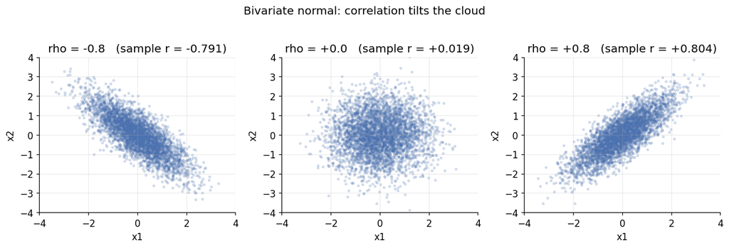

```
Dirichlet(alpha=[2,5,3]) draws (each row sums to 1):
  1: [0.158, 0.510, 0.332]  sum=1.000000
  2: [0.171, 0.237, 0.592]  sum=1.000000
  3: [0.146, 0.496, 0.359]  sum=1.000000
  4: [0.118, 0.132, 0.750]  sum=1.000000
  5: [0.252, 0.643, 0.105]  sum=1.000000
theory mean = alpha/sum(alpha) = [0.2 0.5 0.3]
```

```python
rng = np.random.default_rng(42)
rhos = [-0.8, 0.0, 0.8]
fig, axes = plt.subplots(1, 3, figsize=(12, 3.9))
for ax, rho in zip(axes, rhos):
    cov = [[1.0, rho], [rho, 1.0]]
    s = rng.multivariate_normal([0, 0], cov, size=4000)
    emp = np.corrcoef(s.T)[0, 1]
    ax.scatter(s[:, 0], s[:, 1], s=6, alpha=0.18, color=BLUE)
    ax.set_title(f'rho = {rho:+.1f}   (sample r = {emp:+.3f})')
    ax.set_xlabel('x1'); ax.set_ylabel('x2')
    ax.set_xlim(-4, 4); ax.set_ylim(-4, 4)
fig.suptitle('Bivariate normal: correlation tilts the cloud', y=1.03)
plt.tight_layout(); plt.show()

# Dirichlet: each row is a probability vector (sums to 1).
alpha = [2, 5, 3]
ds = rng.dirichlet(alpha, size=5)
print('Dirichlet(alpha=[2,5,3]) draws (each row sums to 1):')
for i, row in enumerate(ds):
    print(f'  {i+1}: [{row[0]:.3f}, {row[1]:.3f}, {row[2]:.3f}]  sum={row.sum():.6f}')
print('theory mean = alpha/sum(alpha) =', (np.array(alpha)/sum(alpha)).round(3))
```

### Sampling utilities

`rng.choice` is the swiss-army knife: weighted or unweighted, with or without replacement, and **axis-aware** so you can bootstrap whole *rows* of a matrix. This is exactly the engine behind the bootstrap in Chapter 4.

```
bootstrap (with replacement): [10 40 40 30 30 50 10 40 20 10]
subset    (no replacement)  : [20 40 50]
weighted  (favors 40, 50)   : [20 40 40 50 50 50 40 30 40 10]

original rows:
 [[ 0  1  2]
 [ 3  4  5]
 [ 6  7  8]
 [ 9 10 11]
 [12 13 14]]
bootstrap rows:
 [[ 9 10 11]
 [12 13 14]
 [12 13 14]
 [ 3  4  5]
 [ 9 10 11]]
```

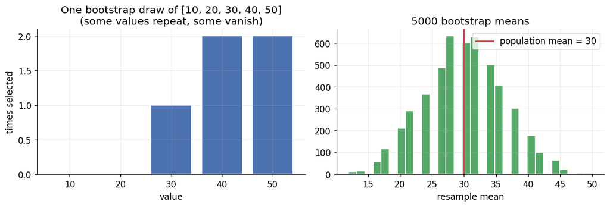

```python
rng = np.random.default_rng(42)
data = np.array([10, 20, 30, 40, 50])

boot = rng.choice(data, size=10, replace=True)              # WITH replacement (bootstrap)
subset = rng.choice(data, size=3, replace=False)            # WITHOUT replacement
weighted = rng.choice(data, size=10, replace=True, p=[0.1, 0.1, 0.1, 0.3, 0.4])
print('bootstrap (with replacement):', boot)
print('subset    (no replacement)  :', subset)
print('weighted  (favors 40, 50)   :', weighted)

X = np.arange(15).reshape(5, 3)
boot_rows = rng.choice(X, size=5, replace=True, axis=0)     # bootstrap whole rows
print('\noriginal rows:\n', X)
print('bootstrap rows:\n', boot_rows)

# Figure: what "with replacement" means -- duplicates appear, and a bootstrap of the
# mean reconstructs the sampling distribution.
rng = np.random.default_rng(7)
pop = np.array([10, 20, 30, 40, 50])
one_draw = rng.choice(pop, size=len(pop), replace=True)
cnt = Counter(one_draw)
boot_means = [rng.choice(pop, size=len(pop), replace=True).mean() for _ in range(5000)]

fig, axes = plt.subplots(1, 2, figsize=(11, 3.8))
axes[0].bar([str(v) for v in pop], [cnt.get(v, 0) for v in pop], color=BLUE, edgecolor='white')
axes[0].set_title(f'One bootstrap draw of {pop.tolist()}\n(some values repeat, some vanish)')
axes[0].set_xlabel('value'); axes[0].set_ylabel('times selected')
axes[1].hist(boot_means, bins=30, color=GREEN, edgecolor='white')
axes[1].axvline(pop.mean(), color=RED, lw=2, label=f'population mean = {pop.mean():.0f}')
axes[1].set_title('5000 bootstrap means'); axes[1].set_xlabel('resample mean'); axes[1].legend()
plt.tight_layout(); plt.show()
```

### Parallel random streams

For parallel computing each worker needs an **independent** stream. Naively using seeds $0,1,2,\dots$ does **not** guarantee independence. NumPy's `SeedSequence` solves this: spawn one child seed per worker, and each child seeds a `Generator` whose stream is statistically independent of the others — and the whole thing is still reproducible from the one parent seed. We estimate $\pi$ on four independent workers.

```python
def mc_pi(child_seed, n_points=1_000_000):
    '''Estimate pi from one worker's independent PCG64 stream.'''
    rng = default_rng(child_seed)
    x, y = rng.random(n_points), rng.random(n_points)
    return 4 * np.sum(x**2 + y**2 <= 1) / n_points

master = SeedSequence(42)
child_seeds = master.spawn(4)              # 4 provably-independent child seeds
estimates = [mc_pi(s) for s in child_seeds]
print('pi from 4 independent workers:', [f'{e:.6f}' for e in estimates])
print(f'combined mean = {np.mean(estimates):.6f}   true pi = {np.pi:.6f}   '
      f'error = {abs(np.mean(estimates)-np.pi):.2e}')
print('\nNEVER share one Generator across threads/processes: that gives race conditions,')
print('correlated streams, and non-reproducible results. Spawn a child per worker.')
```

```
pi from 4 independent workers: ['3.142308', '3.141240', '3.141972', '3.139968']
combined mean = 3.141372   true pi = 3.141593   error = 2.21e-04

NEVER share one Generator across threads/processes: that gives race conditions,
correlated streams, and non-reproducible results. Spawn a child per worker.
```

## F.5 — SciPy stats: the complete statistical toolkit

NumPy *samples* fast; `scipy.stats` supplies the rest of the mathematical infrastructure — density, cumulative, quantile, survival, fitting, and 100+ distributions. Its central design is the **frozen distribution**: build an object with the parameters baked in, then call methods on it.

| Method | Math | Meaning |
| --- | --- | --- |
| `pdf(x)` / `pmf(x)` | $f(x)$ or $P(X=x)$ | density / mass |
| `cdf(x)` | $F(x)=P(X\le x)$ | cumulative |
| `sf(x)` | $1-F(x)$ | survival |
| `ppf(q)` | $F^{-1}(q)$ | quantile (inverse CDF) |
| `rvs(size)` | — | random samples |
| `mean()`, `var()`, `std()` | $E[X]$, $\mathrm{Var}(X)$ | moments |
| `fit(data)` | $\hat\theta_{\text{MLE}}$ | maximum-likelihood fit |

```python
# The frozen-distribution pattern: IQ ~ N(100, 15).
iq = stats.norm(loc=100, scale=15)
print(f'mean = {iq.mean()}   var = {iq.var()}   median = {iq.median()}')
print(f'P(IQ <= 130) = cdf(130) = {iq.cdf(130):.4f}')
print(f'P(IQ >  130) = sf(130)  = {iq.sf(130):.4f}')
print(f'90th percentile = ppf(0.90) = {iq.ppf(0.90):.2f}')
print(f'5 samples = {iq.rvs(size=5, random_state=42).round(1)}')
```

```
mean = 100.0   var = 225.0   median = 100.0
P(IQ <= 130) = cdf(130) = 0.9772
P(IQ >  130) = sf(130)  = 0.0228
90th percentile = ppf(0.90) = 119.22
5 samples = [107.5  97.9 109.7 122.8  96.5]
```

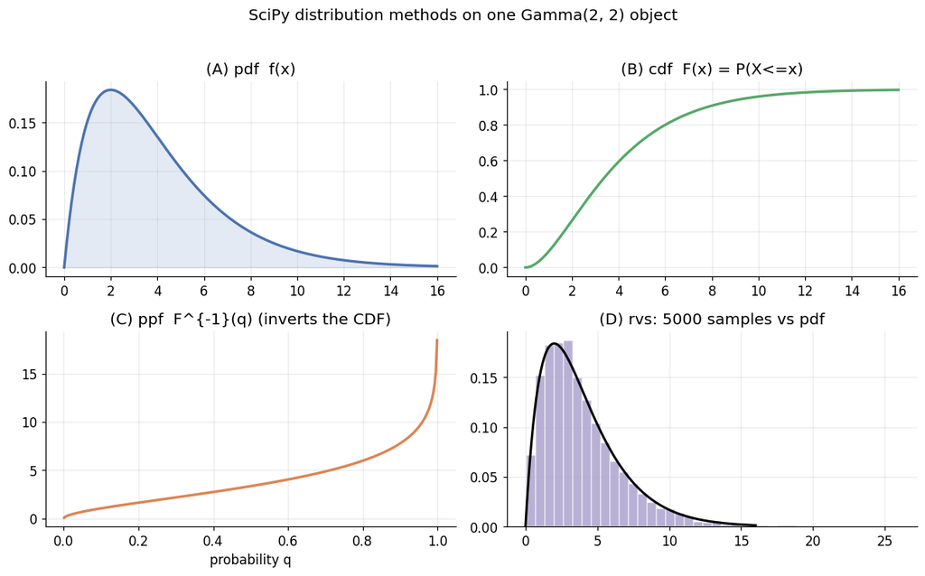

```python
# Figure: the unified interface on one Gamma(a=2, scale=2) -- PDF, CDF, PPF, RVS.
g = stats.gamma(a=2, scale=2)
xx = np.linspace(0, 16, 300)
qq = np.linspace(0.001, 0.999, 300)
samp = g.rvs(size=5000, random_state=0)

fig, axes = plt.subplots(2, 2, figsize=(11, 6.6))
axes[0,0].plot(xx, g.pdf(xx), color=BLUE, lw=2.2); axes[0,0].set_title('(A) pdf  f(x)')
axes[0,0].fill_between(xx, g.pdf(xx), alpha=0.15, color=BLUE)
axes[0,1].plot(xx, g.cdf(xx), color=GREEN, lw=2.2); axes[0,1].set_title('(B) cdf  F(x) = P(X<=x)')
axes[1,0].plot(qq, g.ppf(qq), color=ORANGE, lw=2.2); axes[1,0].set_title('(C) ppf  F^{-1}(q) (inverts the CDF)')
axes[1,0].set_xlabel('probability q')
axes[1,1].hist(samp, bins=40, density=True, color=PURPLE, alpha=0.55, edgecolor='white')
axes[1,1].plot(xx, g.pdf(xx), color='k', lw=2); axes[1,1].set_title('(D) rvs: 5000 samples vs pdf')
fig.suptitle('SciPy distribution methods on one Gamma(2, 2) object', y=1.02)
plt.tight_layout(); plt.show()
```

### Parameterization: the most common error source

Different sources parameterize differently, and SciPy has its own conventions. The worst offender is the **exponential**: textbooks use a *rate* $\lambda$ ($f(x)=\lambda e^{-\lambda x}$, mean $1/\lambda$), while SciPy/NumPy use a *scale* $\beta$ ($f(x)=\frac1\beta e^{-x/\beta}$, mean $\beta$). For a mean of 2 you write `random.expovariate(0.5)` but `rng.exponential(2)` and `stats.expon(scale=2)`. **Always verify by checking the sample mean.**

```python
want_mean = 2.0
correct = stats.expon(scale=2)          # scale = mean -> right
wrong = stats.expon(scale=0.5)          # this has mean 0.5 -> a classic bug
print(f'stats.expon(scale=2): sample mean = {correct.rvs(10000, random_state=42).mean():.3f}  '
      f'(want {want_mean}) -> correct')
print(f'stats.expon(scale=0.5): sample mean = {wrong.rvs(10000, random_state=42).mean():.3f}  '
      f'(want {want_mean}) -> WRONG (scale != rate)')

ref = pd.DataFrame([
    ['Normal',      'stats.norm(loc=mu, scale=sigma)', 'scale is sigma, NOT variance'],
    ['Exponential', 'stats.expon(scale=beta)',         'mean = scale = 1/rate'],
    ['Gamma',       'stats.gamma(a=k, scale=theta)',   'a is shape; mean = k*theta'],
    ['Poisson',     'stats.poisson(mu=lam)',           'mu is the rate lambda'],
    ['NegBinomial', 'stats.nbinom(n, p)',              'counts FAILURES before n successes'],
], columns=['distribution', 'SciPy call', 'gotcha'])
print('\n' + ref.to_string(index=False))
```

```
stats.expon(scale=2): sample mean = 1.955  (want 2.0) -> correct
stats.expon(scale=0.5): sample mean = 0.489  (want 2.0) -> WRONG (scale != rate)

distribution                      SciPy call                             gotcha
      Normal stats.norm(loc=mu, scale=sigma)       scale is sigma, NOT variance
 Exponential         stats.expon(scale=beta)              mean = scale = 1/rate
       Gamma   stats.gamma(a=k, scale=theta)         a is shape; mean = k*theta
     Poisson           stats.poisson(mu=lam)              mu is the rate lambda
 NegBinomial              stats.nbinom(n, p) counts FAILURES before n successes
```

### A complete analysis: fit a Gamma and test the fit

`fit` returns MLEs in one line; `kstest` checks goodness of fit. We generate data from a known $\text{Gamma}(a{=}2,\ \text{scale}{=}2)$, recover the parameters, and run a KS test.

```python
rng = np.random.default_rng(42)
true = stats.gamma(a=2, scale=2)
data = true.rvs(1000, random_state=rng)

a_hat, loc_hat, scale_hat = stats.gamma.fit(data, floc=0)   # fix location at 0
print(f'fitted: shape = {a_hat:.3f}, scale = {scale_hat:.3f}   (true: shape 2.000, scale 2.000)')

fitted = stats.gamma(a=a_hat, loc=loc_hat, scale=scale_hat)
D, p = stats.kstest(data, fitted.cdf)
print(f'KS test: D = {D:.4f}, p = {p:.4f}  -> no evidence of misfit')
print(f'95th percentile: fitted = {fitted.ppf(0.95):.2f}, empirical = {np.percentile(data, 95):.2f}')
print('\nCaveat: parameters were estimated from the SAME data being tested, so the plain')
print('KS p-value is optimistic (the Lilliefors problem); use a parametric bootstrap for a')
print('calibrated test.')
```

```
fitted: shape = 2.002, scale = 1.966   (true: shape 2.000, scale 2.000)
KS test: D = 0.0170, p = 0.9289  -> no evidence of misfit
95th percentile: fitted = 9.33, empirical = 9.43

Caveat: parameters were estimated from the SAME data being tested, so the plain
KS p-value is optimistic (the Lilliefors problem); use a parametric bootstrap for a
calibrated test.
```

## F.6 — Bringing it together: a library selection guide

**Use `random` (standard library)** for zero dependencies, teaching, simple prototypes, sample sizes under ~10,000, and `choice` / `shuffle` / `sample` on lists.

**Use NumPy `Generator`** for arrays and matrices, sample sizes above ~10,000, performance-critical code, multivariate distributions, and parallel streams.

**Use `scipy.stats`** for PDF / CDF / quantile functions, fitting distributions, statistical tests, exact theoretical properties, and exotic distributions.

They **combine** naturally: define and analyze a distribution with SciPy, then sample it efficiently with NumPy.

```python
# Combine: SciPy for definition/analysis, NumPy for fast sampling.
dist = stats.gamma(a=2, scale=3)                 # SciPy: theory side
theory_mean = dist.mean()
crit_95 = dist.ppf(0.95)

rng = np.random.default_rng(42)                  # NumPy: fast sampling side
samples = rng.gamma(shape=2, scale=3, size=100_000)

print(f'theory mean (SciPy)   = {theory_mean}')
print(f'sample mean (NumPy)   = {samples.mean():.4f}')
print(f'95th pct: SciPy ppf   = {crit_95:.3f}   NumPy empirical = {np.percentile(samples, 95):.3f}')
print('-> same model, two libraries, agreeing to sampling precision.')
```

```
theory mean (SciPy)   = 6.0
sample mean (NumPy)   = 6.0044
95th pct: SciPy ppf   = 14.232   NumPy empirical = 14.249
-> same model, two libraries, agreeing to sampling precision.
```

## F.7 — Practice problem: reproducibility & parallel simulation

> Run a simulation study with **4 parallel workers**, each drawing **25,000** samples from a mixture: with probability $0.3$ draw from $N(-2, 1)$, otherwise from $N(3, 0.25)$. (a) build the mixture sampler; (b) give each worker an independent stream with `SeedSequence.spawn()` and check independence; (c) estimate $P(X>0)$ with its Monte-Carlo SE; (d) show reproducibility; (e) show what breaks if all workers share one `Generator`.

**Theory first.** For $X \sim 0.3\,N(-2,1) + 0.7\,N(3,0.25)$: $\;\mathbb E[X] = 0.3(-2)+0.7(3) = 1.5$, and $\mathbb E[X^2] = 0.3(1+4)+0.7(0.25+9) = 7.975$, so $\mathrm{Var}(X) = 7.975 - 1.5^2 = 5.725$ and $\mathrm{SD}(X)\approx 2.393$.

```python
# (a) Mixture sampler -- vectorized with np.where.
def sample_mixture(rng, size):
    '''Sample from 0.3*N(-2,1) + 0.7*N(3,0.5).  rng is a numpy Generator.'''
    component1 = rng.random(size) < 0.3        # True -> component 1 N(-2,1)
    return np.where(component1,
                    rng.normal(-2, 1, size),
                    rng.normal(3, 0.5, size))

rng_test = np.random.default_rng(42)
test = sample_mixture(rng_test, 10000)
print(f'10,000-sample check: mean = {test.mean():.4f} (theory 1.5000), '
      f'std = {test.std():.4f} (theory 2.3927)')
```

```
10,000-sample check: mean = 1.4935 (theory 1.5000), std = 2.3977 (theory 2.3927)
```

```python
# (b) Independent streams via SeedSequence.spawn(); verify near-zero cross-correlation.
parent_seed = 12345
ss = SeedSequence(parent_seed)
child_seeds = ss.spawn(4)
rngs = [default_rng(s) for s in child_seeds]

n_per_worker = 25000
worker_samples = [sample_mixture(r, n_per_worker) for r in rngs]

corr = np.corrcoef(worker_samples)
print(f'parent seed {parent_seed}, 4 workers x {n_per_worker} samples')
print('cross-worker correlation matrix:')
print(np.array2string(corr, precision=4, suppress_small=True))
print(f'expected noise SD ~ 1/sqrt(n) = {1/np.sqrt(n_per_worker):.4f} -> off-diagonals are pure noise.')
```

```
parent seed 12345, 4 workers x 25000 samples
cross-worker correlation matrix:
[[ 1.     -0.0046 -0.0067 -0.0105]
 [-0.0046  1.      0.0005 -0.0021]
 [-0.0067  0.0005  1.      0.0051]
 [-0.0105 -0.0021  0.0051  1.    ]]
expected noise SD ~ 1/sqrt(n) = 0.0063 -> off-diagonals are pure noise.
```

```
total samples : 100,000
P(X > 0) est. : 0.7107   MC SE = 0.001434
95% CI        : (0.7079, 0.7135)
theoretical   : 0.7068   |est - theory| = 0.0038 (~2.7 SE)
```

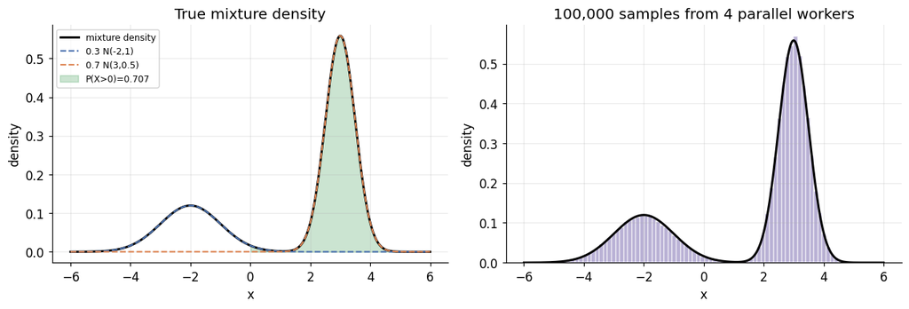

```python
# (c) Estimate P(X > 0) with a Monte-Carlo standard error.
all_samples = np.concatenate(worker_samples)
n_total = len(all_samples)
p_hat = np.mean(all_samples > 0)
se = np.sqrt(p_hat * (1 - p_hat) / n_total)
print(f'total samples : {n_total:,}')
print(f'P(X > 0) est. : {p_hat:.4f}   MC SE = {se:.6f}')
print(f'95% CI        : ({p_hat - 1.96*se:.4f}, {p_hat + 1.96*se:.4f})')

def mixture_cdf(x):
    return 0.3 * stats.norm.cdf(x, -2, 1) + 0.7 * stats.norm.cdf(x, 3, 0.5)
p_theory = 1 - mixture_cdf(0)
print(f'theoretical   : {p_theory:.4f}   |est - theory| = {abs(p_hat - p_theory):.4f} '
      f'(~{abs(p_hat-p_theory)/se:.1f} SE)')

# Figure: the mixture density (P(X>0) shaded) and the 100,000-sample histogram.
xx = np.linspace(-6, 6, 600)
dens = 0.3 * stats.norm.pdf(xx, -2, 1) + 0.7 * stats.norm.pdf(xx, 3, 0.5)
fig, axes = plt.subplots(1, 2, figsize=(11.5, 4.0))
axes[0].plot(xx, dens, color='k', lw=2, label='mixture density')
axes[0].plot(xx, 0.3*stats.norm.pdf(xx,-2,1), '--', color=BLUE, lw=1.4, label='0.3 N(-2,1)')
axes[0].plot(xx, 0.7*stats.norm.pdf(xx,3,0.5), '--', color=ORANGE, lw=1.4, label='0.7 N(3,0.5)')
axes[0].fill_between(xx, dens, where=(xx > 0), color=GREEN, alpha=0.3, label=f'P(X>0)={p_theory:.3f}')
axes[0].set_title('True mixture density'); axes[0].legend(fontsize=8)
axes[1].hist(all_samples, bins=80, density=True, color=PURPLE, alpha=0.55, edgecolor='white')
axes[1].plot(xx, dens, color='k', lw=2)
axes[1].set_title(f'{n_total:,} samples from 4 parallel workers')
for ax in axes: ax.set_xlabel('x'); ax.set_ylabel('density')
plt.tight_layout(); plt.show()
```

```python
# (d) Reproducibility: same parent seed -> bit-identical results.
ss_replay = SeedSequence(parent_seed)
rngs_replay = [default_rng(s) for s in ss_replay.spawn(4)]
worker_replay = [sample_mixture(r, n_per_worker) for r in rngs_replay]
identical = all(np.array_equal(a, b) for a, b in zip(worker_samples, worker_replay))
print('results identical on replay:', identical)
print('worker 0 first 5 (run 1):', worker_samples[0][:5].round(6))
print('worker 0 first 5 (run 2):', worker_replay[0][:5].round(6))
```

```
results identical on replay: True
worker 0 first 5 (run 1): [ 2.888635  3.413628 -2.454651 -1.194422  3.103237]
worker 0 first 5 (run 2): [ 2.888635  3.413628 -2.454651 -1.194422  3.103237]
```

```python
# (e) Why a SHARED generator breaks reproducibility: the result depends on the order
# in which workers happen to draw -- a race condition in real parallel code.
shared = np.random.default_rng(42)
run1_w0 = sample_mixture(shared, 100)   # worker 0 draws first ...
_       = sample_mixture(shared, 100)   # ... then worker 1

shared = np.random.default_rng(42)      # same seed, different scheduling
_       = sample_mixture(shared, 100)   # worker 1 draws first ...
run2_w0 = sample_mixture(shared, 100)   # ... then worker 0

print(f'shared generator, worker 0 mean when it draws FIRST : {run1_w0.mean():+.4f}')
print(f'shared generator, worker 0 mean when it draws SECOND: {run2_w0.mean():+.4f}')
print(f'difference = {abs(run1_w0.mean() - run2_w0.mean()):.4f}  -> NOT reproducible')
print('\nFix: SeedSequence.spawn() gives every worker its own deterministic stream,')
print('independent of execution order (parts b-d).')
```

```
shared generator, worker 0 mean when it draws FIRST : +1.4742
shared generator, worker 0 mean when it draws SECOND: +1.7813
difference = 0.3072  -> NOT reproducible

Fix: SeedSequence.spawn() gives every worker its own deterministic stream,
independent of execution order (parts b-d).
```

## Summary & looking ahead

**Key takeaways.**

1. **Pseudo-randomness is deterministic.** A PRNG's stream is fixed by its seed; reproducibility *requires* explicit seeding. PCG64 (NumPy) is the modern default; Mersenne Twister (Python `random`) is still everywhere but weaker.
2. **Three libraries, three jobs.** `random` for simplicity, NumPy `Generator` for fast array sampling, `scipy.stats` for the full PDF/CDF/quantile/fit toolkit — and they combine.
3. **Know your parameterization.** Rate vs scale causes endless bugs; *always verify the sample mean.*
4. **Vectorize for speed.** NumPy is ~5–10× faster than a Python loop for simple draws.
5. **Independent streams for parallel work.** Use `SeedSequence.spawn()`; never share a `Generator` across workers.

| Need | Reach for | One-liner |
| --- | --- | --- |
| A few random numbers | `random` | `random.random()`, `random.choice(seq)` |
| Fast arrays of draws | NumPy `Generator` | `rng = np.random.default_rng(42); rng.normal(size=n)` |
| PDF / CDF / quantile / fit | `scipy.stats` | `d = stats.norm(0,1); d.cdf(x); d.ppf(q)` |
| Parallel independent streams | `SeedSequence` | `[default_rng(s) for s in SeedSequence(42).spawn(k)]` |

**Looking ahead.** Every Monte-Carlo estimate begins with a call to a random number generator. The uniforms from `default_rng`, the CDFs and PPFs from `scipy.stats`, and the parallel-stream discipline you just practiced are the building blocks for **Chapter 2 (Monte-Carlo methods)**: Monte-Carlo integration, the inverse-CDF method (transforming uniforms with `ppf`), rejection sampling, and variance reduction. The practice problem above *is* the bridge — spawn independent streams, sample, average to estimate a probability — and Chapter 2 develops the theory of why it works.